# Executive Summary: Regression Prediction

Data Science 3 with R (STAT 301-3)

Author

Zosia Alarr

Published

May 29, 2023

## Github Repo Link

https://github.com/zosiaalarr/pred-reg-zosiaalarr.git

## Executive Summary

The goal of this project was to predict a numerical outcome variable based on over 750 other numerical variables. The representation and importance of these variables were unknown, posing a challenge in determining their significance.

The data consisted of two CSV files from an unknown source. One file contained the training data, and the other contained the testing data. To avoid overfitting, the training data was further split into a training and testing set, with 25% of the data reserved for testing. The remaining data was used for cross-validation with 5 folds and 3 repeats. The outcome variable, `y`, exhibited a somewhat right-skewed distribution, indicating the potential benefit of applying a log transformation.

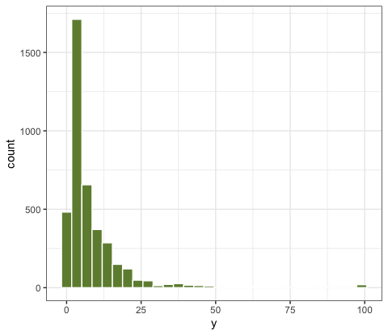

A check for missing values was performed, revealing that none of the variables had more than 20% missing observations, thus justifying the imputation of missing values.

Initially, a lasso variable selection method was employed by creating a “kitchen sink” recipe and running a linear regression model. This approach yielded over 400 variables with non-zero estimates. To narrow down the list, the penalty range was updated to range(0,5), resulting in 20 variables with more substantial estimates. A recipe was then created using these 20 variables, along with `step_nzv`, `step_normalize`, `step_corr`, and `step_impute_mean`. Subsequently, 8 models (mars, svm poly, svm radial, elastic net, random forest, k-nearest neighbors, neural network, boosted tree) were run and fitted to the entire training and testing set. Additionally, a CSV file containing the predicted `y` values and their corresponding IDs was submitted for the official test on Kaggle. The performance metric of choice was an RMSE value. These files were uploaded to Kaggle and their RMSE values were calcutaed based on the model’s predicted `y` values compared to the test sets official `y` value. The models had poor RMSE values ranging from 10 to 9.5. However, the elastic net, random forest, and svm radial models demonstrated relatively lower RMSE values.

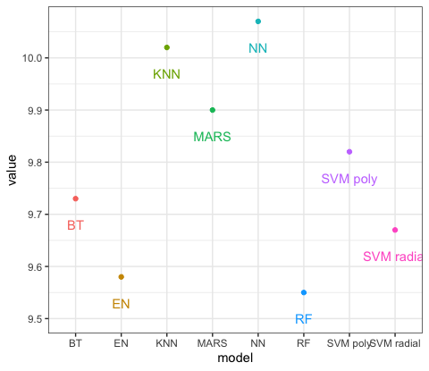

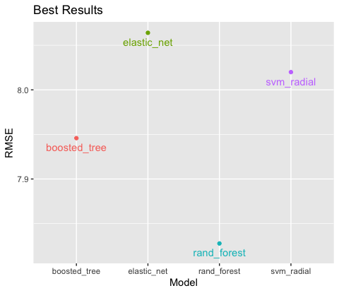

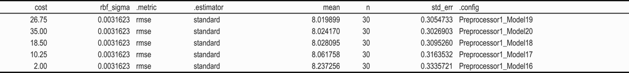

The model also ran with great efficiency.

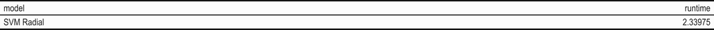

SVM Radial runtime in mins

The next best preforming model an the svm radial model with a different updated `cost` range (0.2,25). The predictions from this model received an RMSE score of 9.05832.

The range of the tuning parameter `rbf_sigma` was also adjusted, but it did not outperform the default range.